# Part II - Reason/s for arrival delay of flights

## Investigation Overview

In this analysis, I wanted to understand the reasons for the arrival delay of flights from flight report of 2008. The main features to look against the arrival delay includes ActualElapsedTime,AirTime,ArrDelay,DepDelay,Origin,Dest,Distance,Diverted,WeatherDelay,NASDelay,SecurityDelay and LateAircraftDelay

## Dataset Overview

```python
# import all packages and set plots to be embedded inline
import numpy as np
import pandas as pd
import matplotlib.pyplot as plt
import seaborn as sb
from matplotlib.pyplot import figure

%matplotlib inline
```

```python
# load the dataset
flights = pd.read_csv("2008.csv")
flights.head(10)
```

|  | Year | Month | DayofMonth | DayOfWeek | DepTime | CRSDepTime | ArrTime | CRSArrTime | UniqueCarrier | FlightNum | ... | TaxiIn | TaxiOut | Cancelled | CancellationCode | Diverted | CarrierDelay | WeatherDelay | NASDelay | SecurityDelay | LateAircraftDelay |
| --- | --- | --- | --- | --- | --- | --- | --- | --- | --- | --- | --- | --- | --- | --- | --- | --- | --- | --- | --- | --- | --- |
| 0 | 2008 | 1 | 3 | 4 | 1343.0 | 1325 | 1451.0 | 1435 | WN | 588 | ... | 4.0 | 9.0 | 0 | NaN | 0 | 16.0 | 0.0 | 0.0 | 0.0 | 0.0 |
| 1 | 2008 | 1 | 3 | 4 | 1125.0 | 1120 | 1247.0 | 1245 | WN | 1343 | ... | 3.0 | 8.0 | 0 | NaN | 0 | NaN | NaN | NaN | NaN | NaN |
| 2 | 2008 | 1 | 3 | 4 | 2009.0 | 2015 | 2136.0 | 2140 | WN | 3841 | ... | 2.0 | 14.0 | 0 | NaN | 0 | NaN | NaN | NaN | NaN | NaN |
| 3 | 2008 | 1 | 3 | 4 | 903.0 | 855 | 1203.0 | 1205 | WN | 3 | ... | 5.0 | 7.0 | 0 | NaN | 0 | NaN | NaN | NaN | NaN | NaN |
| 4 | 2008 | 1 | 3 | 4 | 1423.0 | 1400 | 1726.0 | 1710 | WN | 25 | ... | 6.0 | 10.0 | 0 | NaN | 0 | 16.0 | 0.0 | 0.0 | 0.0 | 0.0 |
| 5 | 2008 | 1 | 3 | 4 | 2024.0 | 2020 | 2325.0 | 2325 | WN | 51 | ... | 13.0 | 7.0 | 0 | NaN | 0 | NaN | NaN | NaN | NaN | NaN |
| 6 | 2008 | 1 | 3 | 4 | 1753.0 | 1745 | 2053.0 | 2050 | WN | 940 | ... | 6.0 | 7.0 | 0 | NaN | 0 | NaN | NaN | NaN | NaN | NaN |
| 7 | 2008 | 1 | 3 | 4 | 622.0 | 620 | 935.0 | 930 | WN | 2621 | ... | 7.0 | 19.0 | 0 | NaN | 0 | NaN | NaN | NaN | NaN | NaN |
| 8 | 2008 | 1 | 3 | 4 | 1944.0 | 1945 | 2210.0 | 2215 | WN | 389 | ... | 7.0 | 15.0 | 0 | NaN | 0 | NaN | NaN | NaN | NaN | NaN |
| 9 | 2008 | 1 | 3 | 4 | 1453.0 | 1425 | 1716.0 | 1650 | WN | 519 | ... | 6.0 | 13.0 | 0 | NaN | 0 | 11.0 | 0.0 | 0.0 | 0.0 | 15.0 |

10 rows × 29 columns

```python
# Extracting Variables interested on for investigating and save to a dataframe.
new_flight = flights[['ActualElapsedTime','AirTime','ArrDelay','DepDelay','Origin','Dest','Distance','Diverted','WeatherDelay','NASDelay','SecurityDelay','LateAircraftDelay']].copy()
```

```python
# removing row containing null values
new_flight.dropna(inplace=True)
```

```python
new_flight['ActualElapsedTime'] = new_flight['ActualElapsedTime'].astype(np.int64)
new_flight['AirTime'] = new_flight['AirTime'].astype(np.int64)
new_flight['ArrDelay'] = new_flight['ArrDelay'].astype(np.int64)
new_flight['DepDelay'] = new_flight['DepDelay'].astype(np.int64)
new_flight['WeatherDelay'] = new_flight['WeatherDelay'].astype(np.int64)
new_flight['NASDelay'] = new_flight['NASDelay'].astype(np.int64)
new_flight['SecurityDelay'] = new_flight['SecurityDelay'].astype(np.int64)
new_flight['LateAircraftDelay'] = new_flight['LateAircraftDelay'].astype(np.int64)
```

```python
# Set the index to have a proper number sequence
new_index = np.arange(0,584583,1)
new_flight.set_index(new_index,inplace=True)
```

```python
# functions to use for all the plot

# Univariate plots
def boxplot_xlim(x,ticks,y_label,a,b):
    '''box plot with limited x values'''
    plt.figure(figsize=(25,5))
    sb.boxplot(data = new_flight,x = x,fliersize = 3,color=sb.color_palette()[0])  # used box plot to understand the distribution
    labels = ['{}'.format(t) for t in ticks]
    plt.xticks(ticks,labels)
    plt.xlabel(x + ' Values',fontsize=20)
    plt.ylabel(y_label,fontsize=20)
    plt.title('Distribution of ' + y_label,fontsize=20)
    plt.xlim(a,b)
    plt.show()

def violin_plot(y,y_label):
    '''function for violin plot'''
    plt.figure(figsize=(8,5))
    sb.violinplot(data = new_flight,y=y , color=sb.color_palette()[0])
    plt.xlabel(y +' Values',fontsize=20)
    plt.ylabel(y_label,fontsize=20)
    plt.title('Distribution of ' + y_label,fontsize=20)
    plt.show()


# Bivariate plot
def scatter(x,y,y_label):
    '''scatter plot'''
    plt.figure(figsize=(10,5))
    sb.regplot(data = new_flight,x = x,y = y,fit_reg=False)
    plt.title('Arrival Delay ' + 'Vs ' + y_label,fontsize=20)
    plt.xlabel('Arrival Delay',fontsize=20)
    plt.ylabel(y_label,fontsize=20)
    plt.show()


def bivariate_boxPlot(x,y,x_label,y_label):
    '''bivariate box plot'''
    plt.figure(figsize=(10,5))
    sb.boxplot(data = new_flight, x = x, y = y, color=sb.color_palette()[0])
    plt.xticks(rotation=90)
    plt.title(x_label + ' Vs ' + y_label,fontsize=20)
    plt.xlabel(x_label,fontsize=20)
    plt.xticks([], [])          # removing the x ticks because of large entries
    plt.show()

# Multivariate plot
def multi_scatter(x,y,c,colorbar_label,z):
    '''multivariate plot'''
    plt.figure(figsize=[10,5])
    plt.scatter(data=new_flight,x = x,y = y,c = c,cmap='viridis_r')
    plt.colorbar(label= colorbar_label)
    plt.title('Arrival Delay ' + 'Vs ' + 'Departure Delay ' + 'Vs ' + z,fontsize=20)
    plt.xlabel('Arrival Delay',fontsize=20)
    plt.ylabel('Departure Delay',fontsize=20)
    plt.show()
```

### Distribution of Arrival delay

ArrDelay being discrete data box plot shows the distribution of the these variable. Looking more closely to the box plot its understood this distribution is right skewed.

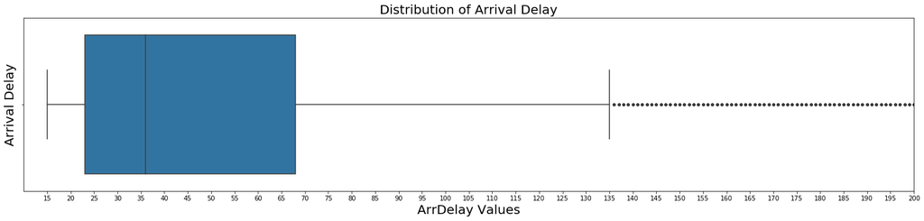

```python
# limiting the data to look closely to the distribution
ticks = np.arange(15,2475,5)
boxplot_xlim('ArrDelay',ticks,'Arrival Delay',10,200)
```

### Distribution of Departure delay

DepDelay being discrete data box plot shows the distribution of the this variable. Looking more closely to the box plot its understood this distribution is positively skewed.

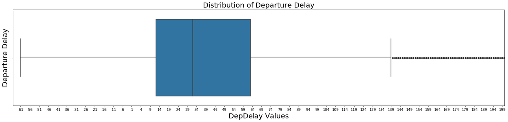

```python
# limiting the data to look closely to the distribution
ticks = np.arange(-61,2520,5)
boxplot_xlim('DepDelay',ticks,'Departure Delay',-65,200)
```

### Distribution of Weather delay

WeatherDelay being discrete data box plot shows the distribution of the this variable. It's understood most records of weather delay are zero indicating majority of airports doesn't have a weather delay on their flights. Eventhough,the distribution shows most all values are equal to the median which is 0, there are outliers observed. Therefore it's positively skewed.

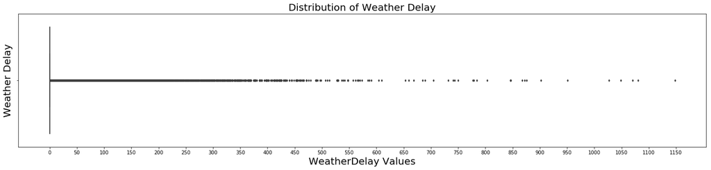

```python
# WeatherDelay using boxplot
ticks = np.arange(0,1151,50)
box_plot('WeatherDelay',ticks,'Weather Delay')
```

Using violin plot to better see the distribution around 0

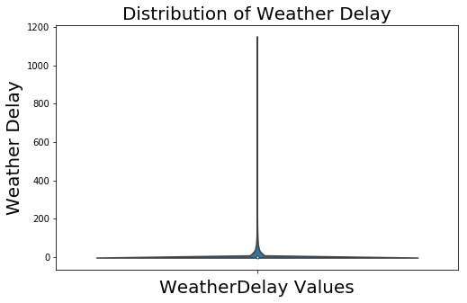

```python
# WeatherDelay using violinplot
violin_plot('WeatherDelay','Weather Delay')
```

### Distribution of NAS delay

NASDelay being discrete data box plot shows the distribution of the this variable. Looking more closely to the box plot its understood this distribution is right skewed.

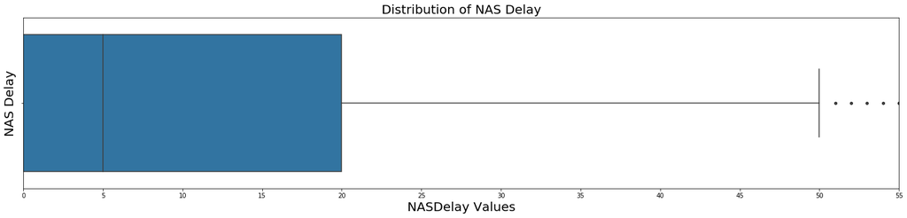

```python
# limiting the data to look closely to the distribution
ticks = np.arange(0,5000,5)
boxplot_xlim('NASDelay',ticks,'NAS Delay',0,55)
```

### Distribution of Security delay

SecurityDelay being discrete data box plot shows the distribution of the this variable. It's understood the majority airports within the dataset have a zero value of SecurityDelay variable, indicating there isn't security delay in most of the flights.Although,this has been stated,there are outliers having different value than 0. Hence this distribution is right skewed.

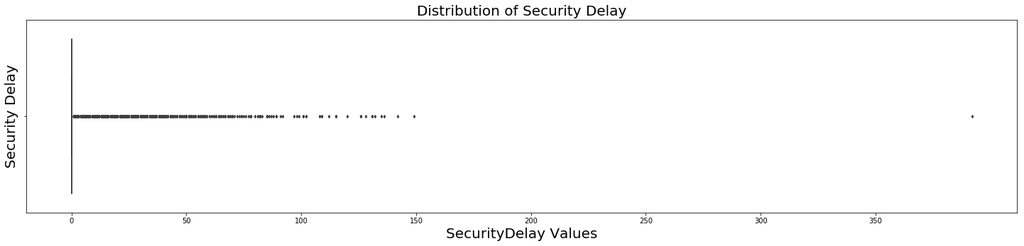

```python
# SecurityDelay using boxplot
ticks = np.arange(0,400,50)
box_plot('SecurityDelay',ticks,'Security Delay')
```

Using violin plot to see the distribution from different angle

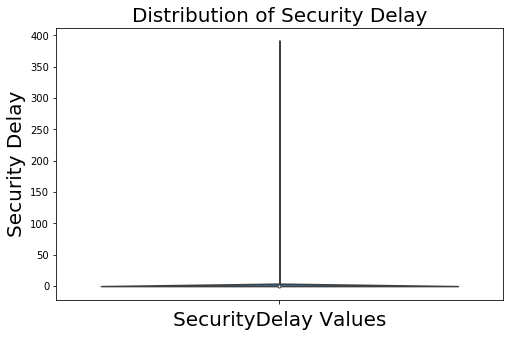

```python
# SecurityDelay using violin
violin_plot('SecurityDelay','Security Delay')
```

### Distribution of Late Aricraft delay

LateAircraftDelay being discrete data box plot shows the distribution of the this variable. Looking more closely to the box plot its understood this distribution is right skewed.

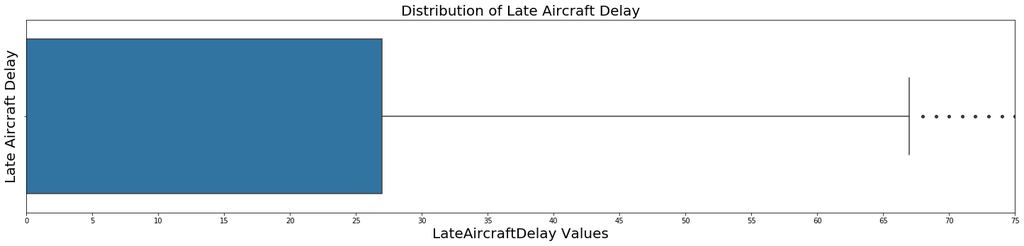

```python
# limiting the data to look closely to the distribution
ticks = np.arange(0,1301,5)
boxplot_xlim('LateAircraftDelay',ticks,'Late Aircraft Delay',0,75)
```

### Arrival Delay relation with Departure Delay

Depicting scater plot for the two numerical variables it's seen they have strong correlation.

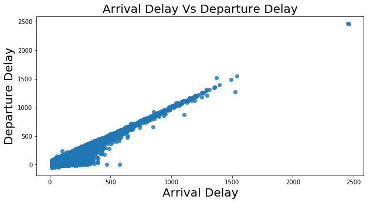

```python
# Arrival Delay and Departure Delay (numerical Vs numerical)
scatter('ArrDelay','DepDelay','Departure Delay')                             # calling function scatter
```

### Arrival Delay relation with Weather Delay

Using both scatter and box plot to better understand how the distribution of WeatherDelay relate with ArrDelay it's observed they have a correlation.

#### Scatter Plot

Arrival Delay versus Weather Delay

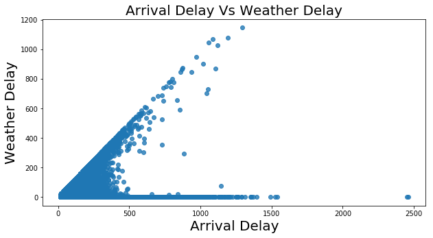

```python
# using box plot to understand the relation better
scatter('ArrDelay','WeatherDelay','Weather Delay')     # calling function bivariate_boxPlot
```

#### Box Plot

Arrival Delay versus Weather Delay

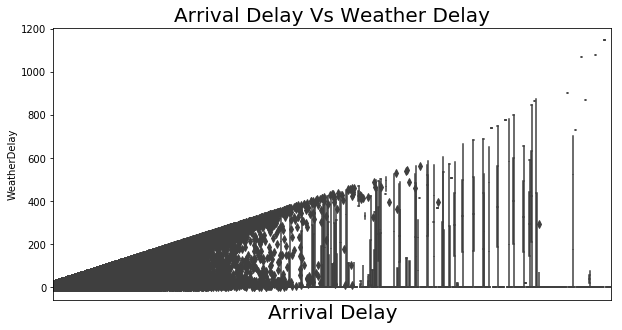

```python
# using box plot to understand the relation better
bivariate_boxPlot('ArrDelay','WeatherDelay','Arrival Delay','Weather Delay')     # calling function bivariate_boxPlot
```

### Arrival Delay relation with NAS Delay

Scatter and Box plot are used to better understand the relation between this two variable. The chart shows a relation of correlation.

#### Scatter Plot

Arrival Delay Versus NAS Delay

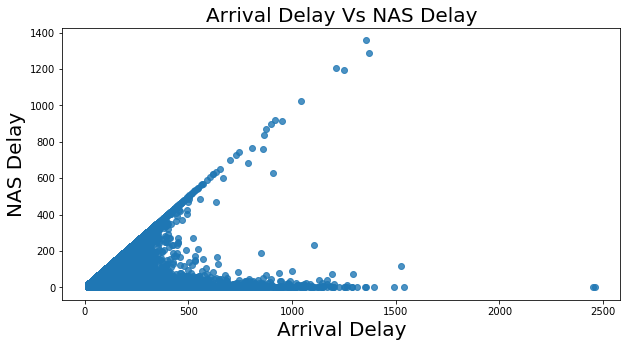

```python
# using box plot to understand the relation better
scatter('ArrDelay','NASDelay','NAS Delay')         # calling function bivariate_boxPlot
```

#### Box Plot

Arrival Delay vs NAS Delay

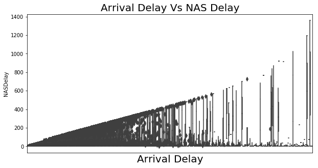

```python
# using box plot to understand the relation better
bivariate_boxPlot('ArrDelay','NASDelay','Arrival Delay','NAS Delay')     # calling function bivariate_boxPlot
```

### Arrival Delay relation with Security Delay

Box plot and Scatter plot are used to better understand the relation between this two variable. The chart depict a relation of correlation.

#### Scatter Plot

Arrival Delay versus Security Delay

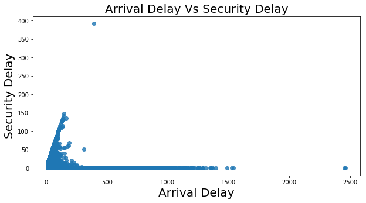

```python
# using box plot to understand the relation better
scatter('ArrDelay','SecurityDelay','Security Delay')    # calling function bivariate_boxPlot
```

#### Box Plot

Arrival Delay versus Security Delay

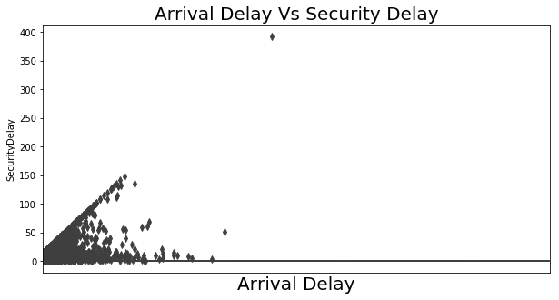

```python
# using box plot to understand the relation better
bivariate_boxPlot('ArrDelay','SecurityDelay','Arrival Delay','Security Delay')     # calling function bivariate_boxPlot
```

### Arrival Delay relation with Late Aircraft Delay

Taking the advantage of box plot to better understand how the distribution of LateAircraftDelay relate with ArrDelay it's observed they have a correlation.

#### Scatter Plot

Arrival Delay versus Late Aircraft Delay

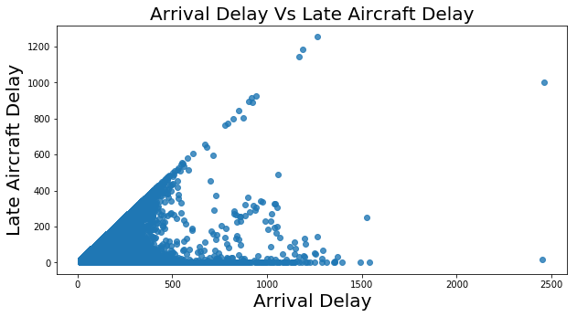

```python
# using box plot to understand the relation better
scatter('ArrDelay','LateAircraftDelay','Late Aircraft Delay') # calling function bivariate_boxPlot
```

#### Box Plot

Arrival Delay versus Late Aircraft Delay

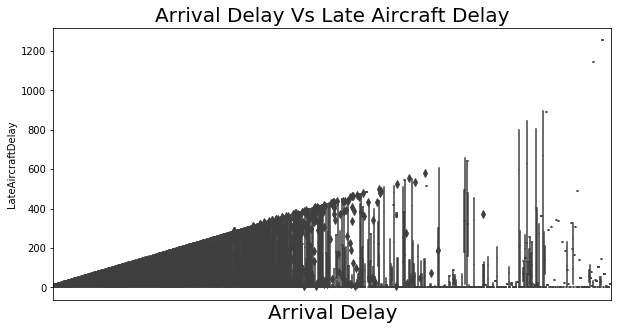

```python
# using box plot to understand the relation better
bivariate_boxPlot('ArrDelay','LateAircraftDelay','Arrival Delay','Late Aircraft Delay')     # calling function bivariate_boxPlot
```

### Arrival Delay with Departure Delay relation to Weather Delay

Plotting arrival delay strong relation with departure delay against weather delay using color. It seems weather delay have correlaion with both variables.

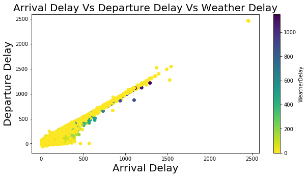

```python
# ArrDelay,DepDelay and WeatherDelay
multi_scatter('ArrDelay','DepDelay','WeatherDelay','WeatherDelay','Weather Delay')       # calling function multi_scatter
```

### Arrival Delay with Departure Delay relation to NAS Delay

Plotting arrival delay strong relation with departure delay against NAS delay using color. It seems NAS delay results in having correlaion with both variables.

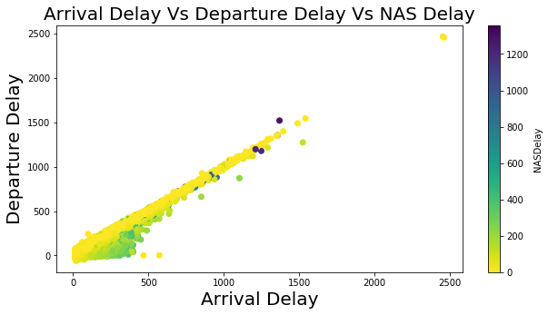

```python
# ArrDelay,DepDelay and NASDelay
multi_scatter('ArrDelay','DepDelay','NASDelay','NASDelay','NAS Delay')       # calling function multi_scatter
```

### Arrival Delay with Departure Delay relation to Security Delay

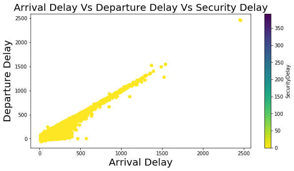

```python
# ArrDelay,DepDelay and SecurityDelay
multi_scatter('ArrDelay','DepDelay','SecurityDelay','SecurityDelay','Security Delay')       # calling function multi_scatter
```

### Arrival Delay with Departure Delay relation to Late Aircraft Delay

Plotting arrival delay strong relation with departure delay using scatter plot and against Late Aircraft delay using color . It depict late aircraft delay have a correlaion with arrival delay and departure delay.

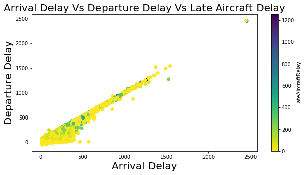

```python
# ArrDelay,DepDelay and LateAircraftDelay
multi_scatter('ArrDelay','DepDelay','LateAircraftDelay','LateAircraftDelay','Late Aircraft Delay')       # calling function multi_scatter
```